# Using Neighborhood Level Data to Predict the Residential Sale Price of Properties in Ames, Iowa

### Overall Quality

The most prominent attribute is overall.qual. It rates the overall material and finish of the house. The values range from Very Poor (1) to Very Excellent (10). I am a bit suspicious of this variable since it is based on a subjective evaluation by the compiler of the data set. The observed tracking with the sale price of the house as shown in the graph that follows may not be quite coincidental. I have created a regression model with the variable and one without it on the grounds that it may obscure other factors that are more reliably grounded.

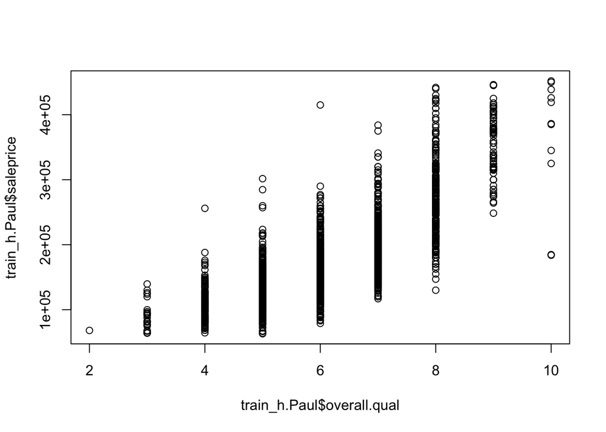

```r
plot(train_h.Paul$overall.qual,train_h.Paul$saleprice)
```

### Location.

The classic real estate refrain says, “location, location, location.” The data from Ames, IA provides a single attribute, neighborhood, that stands in for this concept. Each property is identified by neighborhood. The graph below shows the impact of neighborhood on housing sale price. I re coded Neighborhood to a factor in an order which reflected the mean sale price. This allows a clear display of the changes in sale prices as one moves up to what would seem to be the more upscale locations.

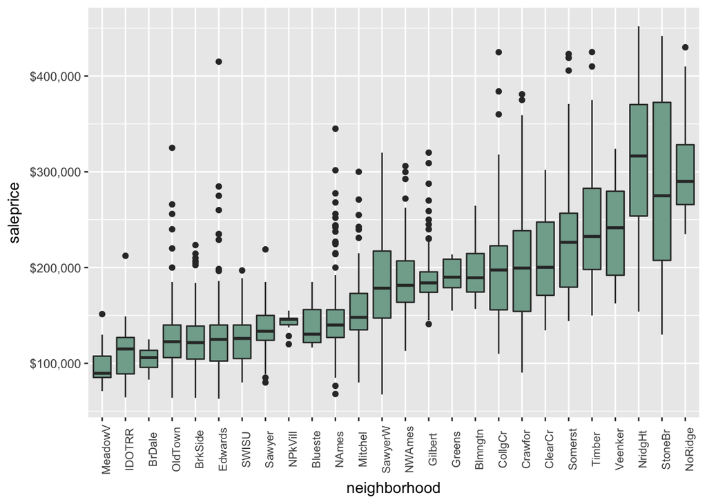

```r
train_h.Paul$neighborhood <- factor(train_h.Paul$neighborhood, levels = c("MeadowV" ,"IDOTRR" ,"BrDale" ,"OldTown" ,"BrkSide" ,"Edwards" ,"SWISU" ,"Sawyer" ,"NPkVill" ,"Blueste" ,"NAmes" ,"Mitchel" ,"SawyerW" ,"NWAmes" ,"Gilbert" ,"Greens" ,"Blmngtn" ,"CollgCr" ,"Crawfor" ,"ClearCr" ,"Somerst" ,"Timber" ,"Veenker" ,"NridgHt" ,"StoneBr" ,"NoRidge"))
test_h.Paul$neighborhood <- factor(test_h.Paul$neighborhood, levels = c("MeadowV" ,"IDOTRR" ,"BrDale" ,"OldTown" ,"BrkSide" ,"Edwards" ,"SWISU" ,"Sawyer" ,"NPkVill" ,"Blueste" ,"NAmes" ,"Mitchel" ,"SawyerW" ,"NWAmes" ,"Gilbert" ,"Greens" ,"Blmngtn" ,"CollgCr" ,"Crawfor" ,"ClearCr" ,"Somerst" ,"Timber" ,"Veenker" ,"NridgHt" ,"StoneBr" ,"NoRidge"))
ggplot(train_h.Paul, aes(x = neighborhood, y = saleprice)) +
  geom_boxplot(fill = "#81AC9B") +
  theme(axis.text.x = element_text(angle = 90, size = 8), legend.position = "none") +
  scale_y_continuous(labels = dollar)
```

### Living area

The size of the home in terms of square feet is used within the real estate community as a mechanism for the development of lists of comparable houses. In the cleaned data set the value is shown in the gr.liv.area. The approximate per sq ft charge in Ames, IA is indicated by the coefficient of the model as approximately $44.

### Basement

A finished basement has a clear value since by itself is a pretty good predictor of the sale price. Both the total square feet and the evaluation of the height of the basement ceiling have been kept in the evaluation. A basement square foot would have an approximate value 0f $21. Bsmt Qual evaluates the height of the basement. We have converted this value to a numeric value from 1 to 6 in ascending indications of quality.

```
   Ex   Excellent (100+ inches)
   Gd   Good (90-99 inches)
   TA   Typical (80-89 inches)
   Fa   Fair (70-79 inches)
   Po   Poor (<70 inches
   NA   No Basement
```

```r
test_h.Paul$bsmt.qual = as.numeric(factor(test_h.Paul$bsmt.qual, levels = c("No Basement", "Po", "Fa", "TA", "Gd", "Ex")))
train_h.Paul$bsmt.qual = as.numeric(factor(train_h.Paul$bsmt.qual, levels = c("No Basement", "Po", "Fa", "TA", "Gd", "Ex")))
```

### Exterior Condition

External Quality evaluates the quality of the material on the exterior using a Poor to Excellent scale. This is subject to some of the same concerns discussed previously under overall.qual. Since first impression often drive sales prices, a factor for external appearance is usefully maintained.

```r
test_h.Paul$exter.qual = as.numeric(factor(test_h.Paul$exter.qual, levels = c("Po", "Fa", "TA", "Gd", "Ex")))
train_h.Paul$exter.qual = as.numeric(factor(train_h.Paul$exter.qual, levels = c("Po", "Fa", "TA", "Gd", "Ex")))
```

### Kitchen Condition

Kitchen Quality is a subjective evaluation using a Poor to Excellent rating stored in kitchen.qual, Real estate agents often cite the lack of new appliances in a kitchen as a price determinant. Without any other more objective criteria in the model, we have decided to keep it in the final model.

```r
test_h.Paul$kitchen.qual = as.numeric(factor(test_h.Paul$kitchen.qual, levels = c("Po", "Fa", "TA", "Gd", "Ex")))
train_h.Paul$kitchen.qual = as.numeric(factor(train_h.Paul$kitchen.qual, levels = c("Po", "Fa", "TA", "Gd", "Ex")))
```

### Garage

The number of significant factors in the top price drivers was a surprise. The importance of garage in determining the sales price may be a cultural artifact of the Ames, IA environment indicating a greater reliance on cars as both a means of transport and a status symbol. Of the four variables that describe the garages, we have elected to keep two, garage,area and garage.finish. The garage.cars variable would seem to overlap with the garage.areas and no clear hierarchy exists for the garage.type.

Garage Finish has been converted to a numeric value from 1 to 4 in ascending indications of quality.

```
   Fin  Finished
   RFn  Rough Finished
   Unf  Unfinished
   None No Garage
```

```r
test_h.Paul$garage.finish = as.numeric(factor(test_h.Paul$garage.finish, levels = c("None", "Unf", "RFn", "Fin")))
train_h.Paul$garage.finish = as.numeric(factor(train_h.Paul$garage.finish, levels = c("None", "Unf", "RFn", "Fin")))
```

### Fireplace

Fireplace quality is a more objectively derived attribute than those cited above. Fireplaces would seem to be a highly prized amenity in Ames, IA. We have converted this value to a numeric value from 1 to 6 in ascending indications of quality.

```
   Ex   Excellent - Exceptional Masonry Fireplace
   Gd   Good - Masonry Fireplace in main level
   TA   Average - Prefabricated Fireplace in main living area or Masonry Fireplace in basement
   Fa   Fair - Prefabricated Fireplace in basement
   Po   Poor - Ben Franklin Stove
   NA   No Fireplace
```

```r
test_h.Paul$fireplace.qu = as.numeric(factor(test_h.Paul$fireplace.qu, levels = c("No Fireplace", "Po", "Fa", "TA", "Gd", "Ex")))
train_h.Paul$fireplace.qu = as.numeric(factor(train_h.Paul$fireplace.qu, levels = c("No Fireplace", "Po", "Fa", "TA", "Gd", "Ex")))
```

### Recently Remodeled

Recent remodeling would seem to be a variable that would tend to indicate the presence of new appliances and updated styles in the property. This value is stored in the cleaned data set as yrs.since.remod.

### Lot Area

Lot Area is often a component of the property tax calculation and is often an indicator of the expected sale price. We have included the ln.lot.area within the model to reflect its impact.

### Summary

The final models with and without the overall.qual is shown below.

```r
model.Paul<-lm(saleprice~neighborhood +
    bsmt.qual +
    total.bsmt.sf +
    gr.liv.area +
    exter.qual +
    kitchen.qual +
    garage.area +
    garage.finish +
    fireplace.qu +
    yrs.since.remod +
    ln.lot.area
    , data = train_h.Paul )

model.Paul2<-lm(saleprice~overall.qual +
    neighborhood +
    bsmt.qual +
    total.bsmt.sf +
    gr.liv.area +
    exter.qual +
    kitchen.qual +
    garage.area +
    fireplace.qu +
    yrs.since.remod     , data = train_h.Paul )

stargazer(model.Paul, model.Paul2, type="text", style="apsr")
```

```
##
## -------------------------------------------------------------------------
##                                           saleprice
##                                (1)                        (2)
## -------------------------------------------------------------------------
## overall.qual                                         11,046.010***
##                                                        (882.103)
## neighborhoodIDOTRR        -14,525.500**                3,320.731
##                            (7,233.715)                (6,829.339)
## neighborhoodBrDale         13,760.720*                 -4,550.722
##                            (7,954.409)                (8,023.997)
## neighborhoodOldTown       -17,347.130***               -2,869.428
##                            (6,439.572)                (6,067.007)
## neighborhoodBrkSide         -3,241.998                10,769.400*
##                            (6,802.626)                (6,480.993)
## neighborhoodEdwards       -15,943.270**                6,602.476
##                            (6,643.531)                (6,106.120)
## neighborhoodSWISU          -15,226.920*                -4,119.429
##                            (8,125.980)                (7,865.011)
## neighborhoodSawyer          -8,587.732                14,113.340**
##                            (6,814.017)                (6,256.236)
## neighborhoodNPkVill        14,971.060*                 -1,466.862
##                            (8,973.114)                (9,043.625)
## neighborhoodBlueste         1,381.418                 -13,411.840
##                            (12,477.830)               (12,492.570)
## neighborhoodNAmes           -7,015.382                13,740.130**
##                            (6,437.422)                (5,909.234)
## neighborhoodMitchel         -7,475.075                15,238.900**
##                            (7,166.642)                (6,585.194)
## neighborhoodSawyerW         -5,805.526                11,502.780*
##                            (6,886.175)                (6,403.195)
## neighborhoodNWAmes          -3,937.522                12,367.670*
##                            (6,862.997)                (6,395.505)
## neighborhoodGilbert         -9,476.822                14,133.430**
##                            (6,941.869)                (6,310.242)
## neighborhoodGreens          15,331.280                 6,674.825
##                            (11,950.160)               (11,972.170)
## neighborhoodBlmngtn          -802.522                  -2,273.020
##                            (8,386.187)                (8,329.742)
## neighborhoodCollgCr         1,521.384                17,436.130***
```

[output cut: 31 more lines]

```
## fireplace.qu               3,566.169***               3,370.640***
##                             (424.372)                  (423.787)
## yrs.since.remod            -252.126***                -199.239***
##                              (43.146)                   (42.911)
## ln.lot.area               19,770.290***
##                            (1,886.917)
## Constant                 -226,059.800***             -80,902.350***
##                            (16,897.880)               (9,193.922)
## N                             1,988                      1,989
## R2                            0.855                      0.856
## Adjusted R2                   0.853                      0.854
## Residual Std. Error   27,138.410 (df = 1952)     27,016.380 (df = 1954)
## F Statistic         329.379*** (df = 35; 1952) 342.611*** (df = 34; 1954)
## -------------------------------------------------------------------------
## *p < .1; **p < .05; ***p < .01
```

```r
p1.Paul <- predict(model.Paul, test_h.Paul)
d.Paul.p1 <- data.frame(p1.Paul, test_h.Paul$saleprice)
saleprice_MSE.1 <- mean((d.Paul.p1[,1]-d.Paul.p1[,2])^2, na.rm=TRUE)
saleprice_RMSE.1 <- sqrt(saleprice_MSE.1)
saleprice_RMSE.1
```

```
## [1] 29931.63
```

```r
Paul2 <- predict(model.Paul2, test_h.Paul)
dPaul.p2 <- data.frame(Paul2, test_h.Paul$saleprice)
saleprice_MSE.1 <- mean((dPaul.p2[,1]-dPaul.p2[,2])^2, na.rm=TRUE)
saleprice_RMSE.1 <- sqrt(saleprice_MSE.1)
saleprice_RMSE.1
```

```
## [1] 29740.15
```

# Principle Component Regression (PCR) - Yesh

PCR is an application of Principle Component Analysis (PCA) to regression modeling. By creating “components,” which are linear transformations of the variables in our dataset, multicollinearity can be minimized by using these components in the regression model, rather than the original variables. This can create a better prediction model, with lower risk of overfitting, than a traditional regression model. However, the ability to interpret the coefficients of the model is lost because each component variable is a linear combination of all the variables in the original dataset.

## Model Generation

Because PCR methods work best with numerical data, we first dropped all factor variables from our training dataset, keeping only integer and numerical datatypes

```r
df_train_num <- df_train

for(i in colnames(df_train)){
  if(is.factor( df_train[[i]] )){
    df_train_num[[i]] <- NULL
  }
}
```

The dataset now contains 40 variables. We then generate a general pcr model using all the variables in the training dataset to predict saleprice.

```r
pcr.saleprice <- pcr(saleprice ~ ., data=df_train_num, scale=TRUE, validation="CV")
```

## Model Selection

In order to select the number of components we want to use for prediction, we examine the RMSE vs Number of Components Plot:

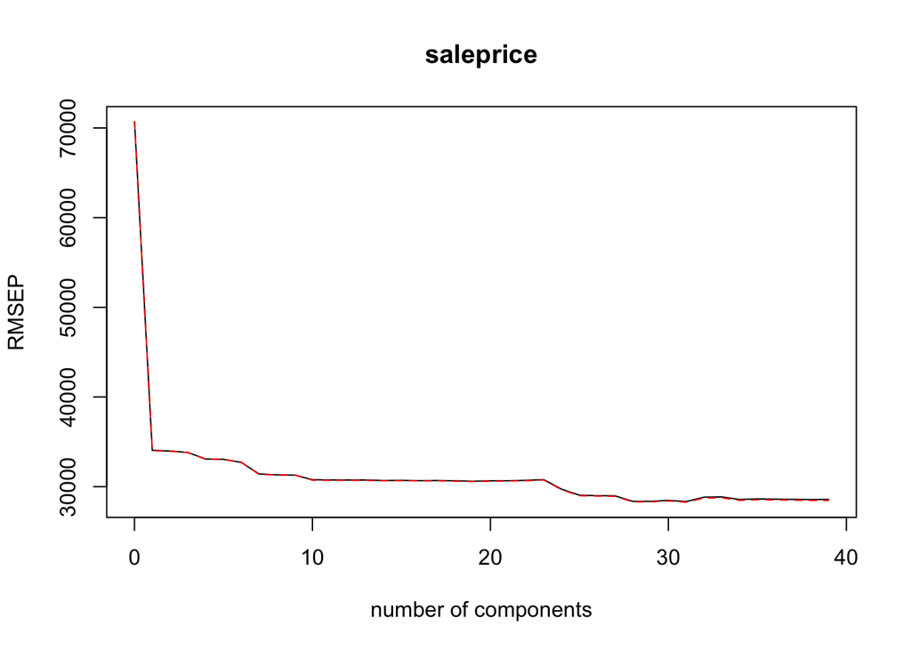

```r
validationplot(pcr.saleprice)
```

And we examine the summary of the model `pcr.saleprice`:

```r
summary(pcr.saleprice)
```

```
## Data:    X dimension: 1989 39
##  Y dimension: 1989 1
## Fit method: svdpc
## Number of components considered: 39
##
## VALIDATION: RMSEP
## Cross-validated using 10 random segments.
##        (Intercept)  1 comps  2 comps  3 comps  4 comps  5 comps  6 comps
## CV           70687    34052    33974    33813    33082    33048    32705
## adjCV        70687    34024    33947    33799    33064    33042    32734
##        7 comps  8 comps  9 comps  10 comps  11 comps  12 comps  13 comps
## CV       31420    31313    31289     30776     30747     30739     30737
## adjCV    31372    31299    31310     30717     30704     30703     30701
##        14 comps  15 comps  16 comps  17 comps  18 comps  19 comps
## CV        30685     30702     30668     30687     30652     30606
## adjCV     30648     30674     30636     30649     30606     30570
##        20 comps  21 comps  22 comps  23 comps  24 comps  25 comps
## CV        30648     30659     30705     30781     29714     29054
## adjCV     30610     30619     30665     30737     29659     28988
##        26 comps  27 comps  28 comps  29 comps  30 comps  31 comps
## CV        28989     28974     28361     28364     28468     28339
## adjCV     28949     28920     28306     28309     28408     28268
##        32 comps  33 comps  34 comps  35 comps  36 comps  37 comps
## CV        28826     28855     28564     28636     28600     28582
## adjCV     28727     28756     28472     28537     28515     28501
##        38 comps  39 comps
## CV        28561     28581
## adjCV     28458     28455
##
## TRAINING: % variance explained
##            1 comps  2 comps  3 comps  4 comps  5 comps  6 comps  7 comps
## X            20.18    30.15    38.99    44.53    48.55    52.23    55.81
## saleprice    76.91    77.03    77.26    78.27    78.33    78.75    80.59
##            8 comps  9 comps  10 comps  11 comps  12 comps  13 comps
## X            58.99    62.01     64.98     67.79     70.46     73.01
## saleprice    80.73    80.85     81.65     81.65     81.71     81.72
##            14 comps  15 comps  16 comps  17 comps  18 comps  19 comps
## X             75.41     77.76     80.03     82.17     84.23     86.23
## saleprice     81.83     81.86     81.93     81.99     82.09     82.16
##            20 comps  21 comps  22 comps  23 comps  24 comps  25 comps
## X             87.99     89.62     91.22     92.71     93.86     94.89
## saleprice     82.17     82.17     82.18     82.19     83.43     84.19
##            26 comps  27 comps  28 comps  29 comps  30 comps  31 comps
## X             95.85     96.76     97.48     98.08     98.61     99.10
## saleprice     84.19     84.36     85.03     85.03     85.04     85.15
##            32 comps  33 comps  34 comps  35 comps  36 comps  37 comps
## X             99.48     99.72     99.92     100.0     100.0    100.00
## saleprice     85.21     85.21     85.39      85.4      85.4     85.42
##            38 comps  39 comps
## X            100.00    100.00
## saleprice     85.42     85.43
```

From the summary and the RSME plot, large jumps in the % of variance explained and RSME are observed from 6 to 7 components, and again from 23 to 24. Three Models will be assessed with 1, 7, and 24 components.

## Model Validation

The table below compares the predicted values to the actual values in the test dataset.

```
##
## ===================================================================
## Statistic          N     Mean      St. Dev.     Min         Max
## -------------------------------------------------------------------
## saleprice.1.comps 849 177,815.800 61,862.660 37,678.950 622,881.700
## df_test.saleprice 849 177,886.600 69,045.960   62,383     455,000
## -------------------------------------------------------------------
##
## ===================================================================
## Statistic          N     Mean      St. Dev.     Min         Max
## -------------------------------------------------------------------
## saleprice.7.comps 849 177,949.800 63,569.530 10,893.610 665,717.100
## df_test.saleprice 849 177,886.600 69,045.960   62,383     455,000
## -------------------------------------------------------------------
##
## ====================================================================
## Statistic           N     Mean      St. Dev.     Min         Max
## --------------------------------------------------------------------
## saleprice.24.comps 849 178,061.700 65,360.610 18,940.550 714,284.500
## df_test.saleprice  849 177,886.600 69,045.960   62,383     455,000
## --------------------------------------------------------------------
```

Comparing the 3 Models, we see the following RMSE Values when applying the model to the test dataset:

- Model 1 (1 Component): $36420
- Model 2 (7 Component): $33924
- Model 3 (24 Component): $33345

# Random Forest Regression - Mike